# Nasal asssimilation analysis - English monolingual

Opening and files and subsetting them.

```r
eval_data = read.csv(paste0(results_folder, "nasal_eval.csv"))



#changing numbers to more meaningful names
eval_data["v_or_c"][eval_data["v_or_c"] == 0] <- "cons."
eval_data["v_or_c"][eval_data["v_or_c"] == 5] <- "vowel"

eval_data["nasal"][eval_data["nasal"] == 1] <- "m"
eval_data["nasal"][eval_data["nasal"] == 2] <- "n"
eval_data["nasal"][eval_data["nasal"] == 3] <- "ɲ"
eval_data["nasal"][eval_data["nasal"] == 4] <- "ŋ"

eval_data["nasal"][eval_data["nasal"] == 6] <- "a"
eval_data["nasal"][eval_data["nasal"] == 7] <- "i"
eval_data["nasal"][eval_data["nasal"] == 8] <- "e"
eval_data["nasal"][eval_data["nasal"] == 9] <- "o"
eval_data["nasal"][eval_data["nasal"] == 10] <- "ɯ"

eval_data["following"][eval_data["following"] == 11] <- "ã"
eval_data["following"][eval_data["following"] == 12] <- "ĩ"
eval_data["following"][eval_data["following"] == 13] <- "ẽ"
eval_data["following"][eval_data["following"] == 14] <- "õ"
eval_data["following"][eval_data["following"] == 15] <- "ũ"

eval_data["following"][eval_data["following"] == 16] <- "labial"
eval_data["following"][eval_data["following"] == 17] <- "coronal"
eval_data["following"][eval_data["following"] == 18] <- "palatal"
eval_data["following"][eval_data["following"] == 19] <- "velar"

eval_data= eval_data[- grep(20, eval_data$nasal),] #deleteing velar nasals bc I could not deal with them


eval_data$following <- as.factor(eval_data$following)  # Convert character column to factor
eval_data$nasal <- as.factor(eval_data$nasal)  # Convert character column to factor
str(eval_data)
```

```
## 'data.frame':    43777 obs. of  6 variables:
##  $ X        : int  31107 31108 31109 31110 31111 31112 31113 31114 31115 31116 ...
##  $ word     : chr  "m a m m a" "p a m m a" "b a m m a" "ɸ a m m a" ...
##  $ v_or_c   : chr  "cons." "cons." "cons." "cons." ...
##  $ nasal    : Factor w/ 9 levels "a","e","i","m",..: 4 4 4 4 4 4 4 4 4 4 ...
##  $ following: Factor w/ 9 levels "ã","coronal",..: 5 5 5 5 5 5 5 5 5 5 ...
##  $ loss_mean: num  -49.4 -53.9 -53.1 -62.7 -53.2 ...
```

```r
cons <- eval_data[eval_data$v_or_c == "cons.", ]
vs <- eval_data[eval_data$v_or_c == "vowel", ]
```

Plotting data

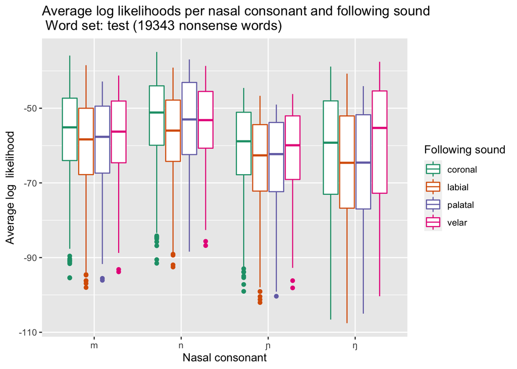

```r
ggplot(cons) +
  geom_boxplot(aes(x=nasal, y=loss_mean, color=following))+
  xlab("Nasal consonant")+
  ylab("Average log  likelihood")+
   ggtitle("Average log likelihoods per nasal consonant and following sound\n Word set: test (19343 nonsense words)")+
  scale_color_brewer(name = "Following sound", palette="Dark2")
```

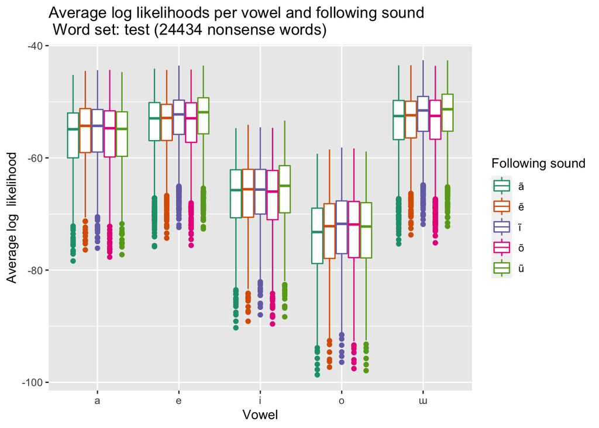

```r
ggplot(vs) +
  geom_boxplot(aes(x=nasal, y=loss_mean, color=following))+
  xlab("Vowel")+
  ylab("Average log  likelihood")+
   ggtitle("Average log likelihoods per vowel and following sound\n Word set: test (24434 nonsense words)")+
  scale_color_brewer(name = "Following sound", palette="Dark2")
```

Descriptive stats.

```r
cons  %>%
  group_by(nasal, following) %>%
  get_summary_stats(loss_mean, type = "mean_sd")
```

| nasal | following | variable | n | mean | sd |
| --- | --- | --- | --- | --- | --- |
| m | coronal | loss_mean | 2100 | -56.501 | 11.161 |
| m | labial | loss_mean | 1674 | -59.835 | 11.988 |
| m | palatal | loss_mean | 349 | -59.120 | 11.854 |
| m | velar | loss_mean | 700 | -57.733 | 10.934 |
| n | coronal | loss_mean | 2020 | -52.644 | 10.677 |
| n | labial | loss_mean | 1750 | -56.918 | 10.703 |
| n | palatal | loss_mean | 350 | -53.811 | 11.731 |
| n | velar | loss_mean | 700 | -54.170 | 9.998 |
| ɲ | coronal | loss_mean | 2100 | -60.386 | 10.761 |
| ɲ | labial | loss_mean | 1750 | -64.403 | 11.432 |

[output cut: 6 more lines]

```r
vs  %>%
  group_by(nasal, following) %>%
  get_summary_stats(loss_mean, type = "mean_sd")
```

| nasal | following | variable | n | mean | sd |
| --- | --- | --- | --- | --- | --- |
| a | ã | loss_mean | 951 | -56.321 | 6.204 |
| a | ẽ | loss_mean | 980 | -55.456 | 5.983 |
| a | ĩ | loss_mean | 980 | -55.498 | 5.820 |
| a | õ | loss_mean | 980 | -56.091 | 6.424 |
| a | ũ | loss_mean | 980 | -56.063 | 6.015 |
| e | ã | loss_mean | 980 | -54.228 | 5.670 |
| e | ẽ | loss_mean | 980 | -54.193 | 5.331 |
| e | ĩ | loss_mean | 970 | -53.330 | 5.152 |
| e | õ | loss_mean | 980 | -54.370 | 5.866 |
| e | ũ | loss_mean | 980 | -53.049 | 5.399 |

[output cut: 15 more lines]

Another way of showing descriptive stats. n – The number of observations for each treatment. mean – The mean value for each treatment. sd – The standard deviation of each treatment. stderr – The standard error of each treatment. That is the standard deviation / sqrt (n). LCL, UCL – The upper and lower confidence intervals of the mean. That is to say, you can be 95% certain that the true mean falls between the lower and upper values specified for each treatment group assuming a normal distribution. median – The median value for each treatment. min, max – The minimum and maximum value for each treatment. IQR – The inner quartile range of each treatment. That is the 75th percentile – 25th percentile. LCLmed, UCLmed – The 95% confidence interval for the median.

```r
cons %>% select(nasal, following, loss_mean) %>% group_by(nasal, following) %>%
  summarise(n=n(),
            mean=mean(loss_mean, na.rm = FALSE),
            sd=sd(loss_mean, na.rm = FALSE),
            stderr=sd/sqrt(n),
            LCL = mean - qt(1 - (0.05 / 2), n - 1) * stderr,
            UCL = mean + qt(1 - (0.05 / 2), n - 1) * stderr,
            median=median(loss_mean, na.rm = FALSE),
            min=min(loss_mean, na.rm = FALSE),
            max=max(loss_mean, na.rm = FALSE),
            IQR=IQR(loss_mean, na.rm = FALSE),
            LCLmed = MedianCI(loss_mean, na.rm=FALSE)[2],
            UCLmed = MedianCI(loss_mean, na.rm=FALSE)[3])
```

| nasal | following | n | mean | sd | stderr | LCL | UCL | median | min | max | IQR | LCLmed | UCLmed |
| --- | --- | --- | --- | --- | --- | --- | --- | --- | --- | --- | --- | --- | --- |
| m | coronal | 2100 | -56.50093 | 11.161334 | 0.2435603 | -56.97858 | -56.02329 | -55.11686 | -95.45492 | -35.89591 | 16.71180 | -55.90048 | -54.22808 |
| m | labial | 1674 | -59.83491 | 11.987811 | 0.2929963 | -60.40958 | -59.26023 | -58.34291 | -98.01976 | -38.47127 | 17.77678 | -59.39580 | -57.41644 |
| m | palatal | 349 | -59.11996 | 11.854157 | 0.6345385 | -60.36797 | -57.87195 | -57.65644 | -96.08667 | -42.84312 | 17.93133 | -59.50735 | -55.40570 |
| m | velar | 700 | -57.73266 | 10.934366 | 0.4132802 | -58.54408 | -56.92125 | -56.26745 | -93.82180 | -41.24957 | 16.53682 | -57.97560 | -54.33272 |
| n | coronal | 2020 | -52.64427 | 10.677418 | 0.2375694 | -53.11017 | -52.17836 | -51.14932 | -91.52980 | -34.92312 | 15.91838 | -52.14478 | -50.43034 |
| n | labial | 1750 | -56.91758 | 10.703471 | 0.2558619 | -57.41941 | -56.41575 | -55.98820 | -92.53276 | -39.12224 | 16.42020 | -56.74412 | -55.03787 |
| n | palatal | 350 | -53.81081 | 11.730547 | 0.6270241 | -55.04404 | -52.57759 | -53.00123 | -88.40721 | -36.92976 | 19.31791 | -54.57754 | -50.95610 |
| n | velar | 700 | -54.17015 | 9.997821 | 0.3778821 | -54.91207 | -53.42823 | -53.18499 | -86.78858 | -38.66835 | 15.20282 | -54.32837 | -51.72078 |
| ɲ | coronal | 2100 | -60.38591 | 10.761225 | 0.2348292 | -60.84643 | -59.92539 | -58.85182 | -99.04142 | -44.56751 | 16.73063 | -59.59746 | -58.12322 |
| ɲ | labial | 1750 | -64.40296 | 11.432419 | 0.2732871 | -64.93896 | -63.86695 | -62.62407 | -102.04326 | -46.67676 | 17.80272 | -63.99702 | -61.35845 |

[output cut: 6 more lines]

```r
vs %>% select(nasal, following, loss_mean) %>% group_by(nasal, following) %>%
  summarise(n=n(),
            mean=mean(loss_mean, na.rm = FALSE),
            sd=sd(loss_mean, na.rm = FALSE),
            stderr=sd/sqrt(n),
            LCL = mean - qt(1 - (0.05 / 2), n - 1) * stderr,
            UCL = mean + qt(1 - (0.05 / 2), n - 1) * stderr,
            median=median(loss_mean, na.rm = FALSE),
            min=min(loss_mean, na.rm = FALSE),
            max=max(loss_mean, na.rm = FALSE),
            IQR=IQR(loss_mean, na.rm = FALSE),
            LCLmed = MedianCI(loss_mean, na.rm=FALSE)[2],
            UCLmed = MedianCI(loss_mean, na.rm=FALSE)[3])
```

| nasal | following | n | mean | sd | stderr | LCL | UCL | median | min | max | IQR | LCLmed | UCLmed |
| --- | --- | --- | --- | --- | --- | --- | --- | --- | --- | --- | --- | --- | --- |
| a | ã | 951 | -56.32109 | 6.204441 | 0.2011928 | -56.71593 | -55.92626 | -54.89881 | -78.37742 | -45.20697 | 8.002494 | -55.38424 | -54.57276 |
| a | ẽ | 980 | -55.45566 | 5.983493 | 0.1911357 | -55.83075 | -55.08058 | -54.28626 | -76.39721 | -44.51070 | 7.833032 | -54.69556 | -53.87794 |
| a | ĩ | 980 | -55.49778 | 5.820082 | 0.1859157 | -55.86262 | -55.13294 | -54.29457 | -76.09830 | -44.37398 | 7.587353 | -54.93048 | -53.99286 |
| a | õ | 980 | -56.09114 | 6.424052 | 0.2052088 | -56.49384 | -55.68844 | -54.71057 | -77.68554 | -44.31727 | 8.220955 | -55.24037 | -54.23326 |
| a | ũ | 980 | -56.06314 | 6.014596 | 0.1921292 | -56.44017 | -55.68611 | -54.83906 | -77.25157 | -44.70985 | 7.933797 | -55.36383 | -54.41983 |
| e | ã | 980 | -54.22833 | 5.669971 | 0.1811206 | -54.58376 | -53.87290 | -52.95639 | -75.82224 | -44.10310 | 6.790277 | -53.25178 | -52.62497 |
| e | ẽ | 980 | -54.19295 | 5.330837 | 0.1702873 | -54.52712 | -53.85878 | -52.88542 | -74.29171 | -44.32358 | 6.435761 | -53.36947 | -52.57088 |
| e | ĩ | 970 | -53.33033 | 5.152097 | 0.1654239 | -53.65496 | -53.00570 | -52.24866 | -72.39376 | -43.55887 | 6.110501 | -52.60736 | -51.87373 |
| e | õ | 980 | -54.36973 | 5.866372 | 0.1873944 | -54.73747 | -54.00199 | -52.94652 | -75.59228 | -44.25952 | 7.057876 | -53.35309 | -52.64944 |
| e | ũ | 980 | -53.04874 | 5.398603 | 0.1724520 | -53.38716 | -52.71032 | -51.86648 | -72.65578 | -43.55401 | 6.427798 | -52.24733 | -51.49363 |

[output cut: 15 more lines]

Checking for outliers: there is only one, I will keep it since its low likelihood is expected ( n+ velar).

```r
outs <- eval_data %>%
  group_by(following) %>%
  identify_outliers(loss_mean)
```

Inferential stats.

```r
model1 <- lm(log(-1*loss_mean) ~ nasal*following, data = cons)
model2 <- lm(log(-1*loss_mean)  ~ nasal+following, data = cons)


model.set <- list(model1, model2)
model.names <- c("int", "2way")

aictab(model.set, model.names)
```

|  | Modnames | K | AICc | Delta_AICc | ModelLik | AICcWt | LL | Cum.Wt |
| --- | --- | --- | --- | --- | --- | --- | --- | --- |
| 1 | int | 17 | -7581.005 | 0.00000 | 1.000000e+00 | 1.000000e+00 | 3807.518 | 1 |
| 2 | 2way | 8 | -7531.339 | 49.66532 | 1.641772e-11 | 1.641772e-11 | 3773.673 | 1 |

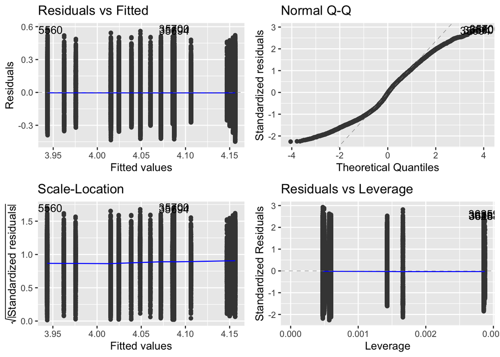

```r
autoplot(model1)
```

```r
summary(model1)
```

```
##
## Call:
## lm(formula = log(-1 * loss_mean) ~ nasal * following, data = cons)
##
## Residuals:
##      Min       1Q   Median       3Q      Max
## -0.44904 -0.16877 -0.00599  0.15220  0.58199
##
## Coefficients:
##                          Estimate Std. Error t value Pr(>|t|)
## (Intercept)              4.015360   0.004339 925.506  < 2e-16 ***
## nasaln                  -0.071745   0.006196 -11.579  < 2e-16 ***
## nasalɲ                   0.070169   0.006136  11.436  < 2e-16 ***
## nasalŋ                   0.071752   0.006136  11.694  < 2e-16 ***
## followinglabial          0.056743   0.006514   8.711  < 2e-16 ***
## followingpalatal         0.044969   0.011493   3.913 9.16e-05 ***
## followingvelar           0.023302   0.008677   2.685  0.00725 **
## nasaln:followinglabial   0.024159   0.009197   2.627  0.00863 **
## nasalɲ:followinglabial   0.007773   0.009157   0.849  0.39596
## nasalŋ:followinglabial   0.012415   0.009157   1.356  0.17518
## nasaln:followingpalatal -0.026155   0.016266  -1.608  0.10786
## nasalɲ:followingpalatal  0.016467   0.016263   1.013  0.31129
## nasalŋ:followingpalatal  0.021669   0.016243   1.334  0.18222
## nasaln:followingvelar    0.008764   0.012302   0.712  0.47623
## nasalɲ:followingvelar   -0.002637   0.012271  -0.215  0.82983
## nasalŋ:followingvelar   -0.061565   0.012640  -4.871 1.12e-06 ***
## ---
## Signif. codes:  0 '***' 0.001 '**' 0.01 '*' 0.05 '.' 0.1 ' ' 1
##
## Residual standard error: 0.1988 on 19327 degrees of freedom
## Multiple R-squared:  0.09811,    Adjusted R-squared:  0.09741
## F-statistic: 140.2 on 15 and 19327 DF,  p-value: < 2.2e-16
```

```r
emmeans(model1, list(pairwise~nasal*following))
```

```
## $`emmeans of nasal, following`
##  nasal following emmean       SE    df lower.CL upper.CL
##  m     coronal    4.015 0.004339 19327    4.007    4.024
##  n     coronal    3.944 0.004424 19327    3.935    3.952
##  ɲ     coronal    4.086 0.004339 19327    4.077    4.094
##  ŋ     coronal    4.087 0.004339 19327    4.079    4.096
##  m     labial     4.072 0.004859 19327    4.063    4.082
##  n     labial     4.025 0.004753 19327    4.015    4.034
##  ɲ     labial     4.150 0.004753 19327    4.141    4.159
##  ŋ     labial     4.156 0.004753 19327    4.147    4.166
##  m     palatal    4.060 0.010642 19327    4.039    4.081
##  n     palatal    3.962 0.010627 19327    3.942    3.983
##  ɲ     palatal    4.147 0.010658 19327    4.126    4.168
##  ŋ     palatal    4.154 0.010627 19327    4.133    4.175
##  m     velar      4.039 0.007515 19327    4.024    4.053
##  n     velar      3.976 0.007515 19327    3.961    3.990
##  ɲ     velar      4.106 0.007515 19327    4.091    4.121
##  ŋ     velar      4.049 0.008103 19327    4.033    4.065
##
## Results are given on the log (not the response) scale.
## Confidence level used: 0.95
##
## $`pairwise differences of nasal, following`
##  1                     estimate      SE    df t.ratio p.value
##  m coronal - n coronal  0.07174 0.00620 19327  11.579  <.0001
##  m coronal - ɲ coronal -0.07017 0.00614 19327 -11.436  <.0001
##  m coronal - ŋ coronal -0.07175 0.00614 19327 -11.694  <.0001
##  m coronal - m labial  -0.05674 0.00651 19327  -8.711  <.0001
##  m coronal - n labial  -0.00916 0.00644 19327  -1.423  0.9897
##  m coronal - ɲ labial  -0.13469 0.00644 19327 -20.930  <.0001
##  m coronal - ŋ labial  -0.14091 0.00644 19327 -21.897  <.0001
##  m coronal - m palatal -0.04497 0.01149 19327  -3.913  0.0090
##  m coronal - n palatal  0.05293 0.01148 19327   4.611  0.0005
##  m coronal - ɲ palatal -0.13160 0.01151 19327 -11.437  <.0001
##  m coronal - ŋ palatal -0.13839 0.01148 19327 -12.056  <.0001
##  m coronal - m velar   -0.02330 0.00868 19327  -2.686  0.3398
##  m coronal - n velar    0.03968 0.00868 19327   4.573  0.0005
##  m coronal - ɲ velar   -0.09083 0.00868 19327 -10.468  <.0001
##  m coronal - ŋ velar   -0.03349 0.00919 19327  -3.643  0.0242
##  n coronal - ɲ coronal -0.14191 0.00620 19327 -22.904  <.0001
```

[output cut: 92 more lines]

```
##  ɲ palatal - ɲ velar    0.04077 0.01304 19327   3.126  0.1213
##  ɲ palatal - ŋ velar    0.09812 0.01339 19327   7.328  <.0001
##  ŋ palatal - m velar    0.11509 0.01302 19327   8.842  <.0001
##  ŋ palatal - n velar    0.17807 0.01302 19327  13.681  <.0001
##  ŋ palatal - ɲ velar    0.04756 0.01302 19327   3.654  0.0234
##  ŋ palatal - ŋ velar    0.10490 0.01336 19327   7.849  <.0001
##  m velar - n velar      0.06298 0.01063 19327   5.926  <.0001
##  m velar - ɲ velar     -0.06753 0.01063 19327  -6.355  <.0001
##  m velar - ŋ velar     -0.01019 0.01105 19327  -0.922  0.9999
##  n velar - ɲ velar     -0.13051 0.01063 19327 -12.281  <.0001
##  n velar - ŋ velar     -0.07317 0.01105 19327  -6.621  <.0001
##  ɲ velar - ŋ velar      0.05734 0.01105 19327   5.189  <.0001
##
## Results are given on the log (not the response) scale.
## P value adjustment: tukey method for comparing a family of 16 estimates
```

```r
model3 <- lm(log(-1*loss_mean) ~ nasal*following, data = vs)
model4 <- lm(log(-1*loss_mean) ~ nasal+following, data = vs)
model.set <- list(model3, model4)
model.names <- c("int", "2way")
aictab(model.set, model.names)
```

|  | Modnames | K | AICc | Delta_AICc | ModelLik | AICcWt | LL | Cum.Wt |
| --- | --- | --- | --- | --- | --- | --- | --- | --- |
| 1 | int | 26 | -44340.36 | 0.00000 | 1.000000e+00 | 9.999998e-01 | 22196.21 | 0.9999998 |
| 2 | 2way | 10 | -44309.25 | 31.10809 | 1.757781e-07 | 1.757780e-07 | 22164.63 | 1.0000000 |

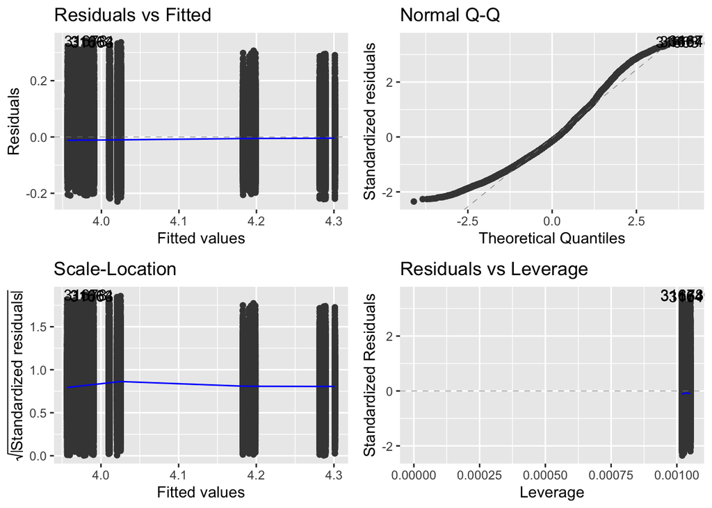

```r
autoplot(model3)
```

```r
summary(model3)
```

```
##
## Call:
## lm(formula = log(-1 * loss_mean) ~ nasal * following, data = vs)
##
## Residuals:
##      Min       1Q   Median       3Q      Max
## -0.22934 -0.06997 -0.01393  0.06139  0.34179
##
## Coefficients:
##                    Estimate Std. Error  t value Pr(>|t|)
## (Intercept)        4.025277   0.003165 1271.805  < 2e-16 ***
## nasale            -0.037202   0.004443   -8.374  < 2e-16 ***
## nasali             0.171117   0.004443   38.516  < 2e-16 ***
## nasalo             0.275954   0.004443   62.113  < 2e-16 ***
## nasalɯ            -0.045232   0.004443  -10.181  < 2e-16 ***
## followingẽ        -0.015274   0.004443   -3.438 0.000587 ***
## followingĩ        -0.014219   0.004443   -3.201 0.001374 **
## followingõ        -0.004561   0.004443   -1.027 0.304644
## followingũ        -0.004323   0.004443   -0.973 0.330578
## nasale:followingẽ  0.015176   0.006259    2.425 0.015334 *
## nasali:followingẽ  0.012220   0.006273    1.948 0.051431 .
## nasalo:followingẽ  0.003166   0.006259    0.506 0.613040
## nasalɯ:followingẽ  0.013124   0.006259    2.097 0.036025 *
## nasale:followingĩ -0.001775   0.006267   -0.283 0.776993
## nasali:followingĩ  0.008562   0.006259    1.368 0.171360
## nasalo:followingĩ -0.005390   0.006259   -0.861 0.389144
## nasalɯ:followingĩ -0.006001   0.006259   -0.959 0.337698
## nasale:followingõ  0.006822   0.006259    1.090 0.275773
## nasali:followingõ  0.006931   0.006259    1.107 0.268171
## nasalo:followingõ -0.009798   0.006264   -1.564 0.117795
## nasalɯ:followingõ  0.006455   0.006259    1.031 0.302410
## nasale:followingũ -0.017424   0.006259   -2.784 0.005379 **
## nasali:followingũ -0.009300   0.006259   -1.486 0.137336
## nasalo:followingũ -0.007902   0.006259   -1.262 0.206796
## nasalɯ:followingũ -0.019153   0.006263   -3.058 0.002229 **
## ---
## Signif. codes:  0 '***' 0.001 '**' 0.01 '*' 0.05 '.' 0.1 ' ' 1
##
## Residual standard error: 0.0976 on 24409 degrees of freedom
## Multiple R-squared:  0.6326, Adjusted R-squared:  0.6322
## F-statistic:  1751 on 24 and 24409 DF,  p-value: < 2.2e-16
```

```r
emmeans(model3, list(pairwise~nasal*following))
```

```
## $`emmeans of nasal, following`
##  nasal following emmean       SE    df lower.CL upper.CL
##  a     ã          4.025 0.003165 24409    4.019    4.031
##  e     ã          3.988 0.003118 24409    3.982    3.994
##  i     ã          4.196 0.003118 24409    4.190    4.203
##  o     ã          4.301 0.003118 24409    4.295    4.307
##  ɯ     ã          3.980 0.003118 24409    3.974    3.986
##  a     ẽ          4.010 0.003118 24409    4.004    4.016
##  e     ẽ          3.988 0.003118 24409    3.982    3.994
##  i     ẽ          4.193 0.003145 24409    4.187    4.200
##  o     ẽ          4.289 0.003118 24409    4.283    4.295
##  ɯ     ẽ          3.978 0.003118 24409    3.972    3.984
##  a     ĩ          4.011 0.003118 24409    4.005    4.017
##  e     ĩ          3.972 0.003134 24409    3.966    3.978
##  i     ĩ          4.191 0.003118 24409    4.185    4.197
##  o     ĩ          4.282 0.003118 24409    4.276    4.288
##  ɯ     ĩ          3.960 0.003118 24409    3.954    3.966
##  a     õ          4.021 0.003118 24409    4.015    4.027
##  e     õ          3.990 0.003118 24409    3.984    3.996
##  i     õ          4.199 0.003118 24409    4.193    4.205
##  o     õ          4.287 0.003127 24409    4.281    4.293
##  ɯ     õ          3.982 0.003118 24409    3.976    3.988
##  a     ũ          4.021 0.003118 24409    4.015    4.027
##  e     ũ          3.966 0.003118 24409    3.960    3.972
##  i     ũ          4.183 0.003118 24409    4.177    4.189
##  o     ũ          4.289 0.003118 24409    4.283    4.295
##  ɯ     ũ          3.957 0.003124 24409    3.950    3.963
##
## Results are given on the log (not the response) scale.
## Confidence level used: 0.95
##
## $`pairwise differences of nasal, following`
##  1          estimate      SE    df t.ratio p.value
##  a ã - e ã  3.72e-02 0.00444 24409   8.374  <.0001
##  a ã - i ã -1.71e-01 0.00444 24409 -38.516  <.0001
##  a ã - o ã -2.76e-01 0.00444 24409 -62.113  <.0001
##  a ã - ɯ ã  4.52e-02 0.00444 24409  10.181  <.0001
##  a ã - a ẽ  1.53e-02 0.00444 24409   3.438  0.1003
##  a ã - e ẽ  3.73e-02 0.00444 24409   8.396  <.0001
##  a ã - i ẽ -1.68e-01 0.00446 24409 -37.665  <.0001
```

[output cut: 281 more lines]

```
##  ɯ õ - o ũ -3.07e-01 0.00441 24409 -69.641  <.0001
##  ɯ õ - ɯ ũ  2.54e-02 0.00441 24409   5.748  <.0001
##  a ũ - e ũ  5.46e-02 0.00441 24409  12.389  <.0001
##  a ũ - i ũ -1.62e-01 0.00441 24409 -36.699  <.0001
##  a ũ - o ũ -2.68e-01 0.00441 24409 -60.793  <.0001
##  a ũ - ɯ ũ  6.44e-02 0.00441 24409  14.587  <.0001
##  e ũ - i ũ -2.16e-01 0.00441 24409 -49.088  <.0001
##  e ũ - o ũ -3.23e-01 0.00441 24409 -73.181  <.0001
##  e ũ - ɯ ũ  9.76e-03 0.00441 24409   2.211  0.8790
##  i ũ - o ũ -1.06e-01 0.00441 24409 -24.093  <.0001
##  i ũ - ɯ ũ  2.26e-01 0.00441 24409  51.249  <.0001
##  o ũ - ɯ ũ  3.32e-01 0.00441 24409  75.318  <.0001
##
## Results are given on the log (not the response) scale.
## P value adjustment: tukey method for comparing a family of 25 estimates
```